# DATA-413/613 HW 01

Author

# Specific Instructions

1. Complete both the Admin elements and the Analysis Elements using the starter document.
2. Prior to completing the Admin elements
   1. Upload a photo (head-shot) of yourself into your canvas profile.
   2. Review the Syllabus, the [academic integrity code](https://www.american.edu/policies/students/upload/academic-integrity-code-2020-2-2.pdf) and the General Instructions for Assignments on Canvas.
   3. Update your Student Info spreadsheet under the Canvas Collaboration site as needed.
3. For the Analysis elements
- Clone the assignment repo to your homework directory as a new repo.
- Rename the starter file under the analysis directory and replace ”starter” with your name and use this file for your solutions.
- Edit the “author” field in the YAML header to use your full name.
- Review the provided assignment HTML file for detailed instructions, the rubric, and to see any images to be replicated.
- Stage and commit your quarto (.qmd) file each time you answer a part of a question, e.g. 1.1.
- Render to HTML (no PDF or .docx) and push to GitHub after each main question, e.g., 1.0 or 2.0. **Committing and Pushing are graded elements for this homework.**
4. After completion of Admin and Analysis elements
- Check your files are named in accordance with the instructions and in the proper directories.
- Check your code is reasonably compliant with [The tidyverse style guide](https://style.tidyverse.org/), e.g., proper use of pipe to break up lines, proper spacing of code, and no lines over 80 characters.
- Re-render to HTML prior to staging, committing, and pushing your final submission.
- Check your output to ensure all images are present and there is no excessive data being shown.
- Once satisfied the assignment is complete, stage, commit, and push your repo to GitHub.
5. After Assignment is complete and pushed to GitHub.
- Go to the canvas Assignment.
- Click “Start Assignment.”
- Enter the phrase: “Assignment is completed, rendered, pushed to GitHub and ready for evaluation.”
- Click “Submit Assignment.

Use Pull requests and or email to ask me any questions. **If you email, please ensure your most recent code is pushed to GitHub.**

If you would like to meet for office hours, please email me with proposed times to meet on Zooms and your questions.

# Learning Outcomes:

- Operate with Git and GitHub.
- Apply concepts and methods from DATA-412/612 to real-world data including functions for data manipulation, plotting, and statistical methods and to interpret results.
- Use RStudio Help and Posit Cheat Sheets (Help/Cheat Sheets) to optimize use of function arguments for clearer. more concise, code.

# Grading Criteria/Rubric

| Question.Part | Points | Topic |
| --- | --- | --- |
| Admin.1 | .50 | Photo |
| Admin.2 | .50 | Syllabus Review |
| Admin.3 | .50 | Academic Integrity Review and Commitment |
| Admin.4 | .50 | Reviewed General Instructions |
| Admin.4 | .50 | Student Info Confirmed |
| Admin.4 | .50 | Updated software for course |
| 1.1 | 1.00 | Load data using a readr function and a relative path and argument to convert NULL to `NA`. Glimpse the data. |
| 1.2 | 1.00 | Identify character data that should be numeric and the reason why it’s read in as character. |
| 1.3 | .50 | Use readr function to reload data with argument to adjust data to numeric. |
| 1.4a | 1.50 | Appropriate plot with smoother for Faculty Salary. Reduced overplotting with smoother and facet. |
| 1.4b | .50 | Reasonable Interpretation of Faculty Salary and Earnings |
| 1.4c | .50 | Correct explanation for smoother method |
| 1.4d | .50 | Explanation for no ICLEVEL 3 plot/data |
| 1.4e | 1.00 | Correct Linear model |
| 1.4f | .50 | Correct results from glance() |
| 1.4g | 1.00 | Interpretation of linear model using p value and adjusted r-squared. |
| 1.4h | .50 | Reasonable Recommendation |
| 1.5a | 2.00 | Reproduce Level of Institution plot with correct data, theme, and all labels |
| 1.5b | .50 | Reasonable interpretation of Level of Institution and Median Earnings |
| 1.5c | 1.00 | Proper aov model |
| 1.5d | 1.00 | tidy results and reasonable interpretation |
| 1.5e | .50 | Reasonable explanation |
| 1.6a | 2.00 | Proper plot for Earnings by % women with appropriate data, aesthetics, smoothers, scales, and text. |
| 1.6b | 1.00 | Reasonable interpretation and answers |
| 1.6c | 1.00 | Correct results and reasonable discussion |
| 1.6d | 1.00 | Proper plot with filtered data |
| 1.6d-ec | 1.00 | Proper points and labels that are dynamic |
| 1.6e | .50 | Reasonable discussion |
| 1.6f | .50 | Proper linear model |
| 1.6g | 1.00 | Proper results and reasonable interpretation |
| 1.7a | 2.50 | Proper plot for Earnings by race/ethnicity with appropriate data, aesthetics, smoothers, scales, and text. |
| 1.7b | 1.00 | Reasonable interpretation and answers |
| 1.7c | 1.00 | Reasonable discussion. |
| 1.8a | .50 | Correct data |
| 1.8b | .50 | Correct new variable |
| 1.8c | 1.00 | Correct rank |
| 1.8d | 1.00 | Correct Top and Bottom 5 with proper display of data. |
| 1.8e | .50 | Correct AU Rank |
| 1.8.f.ec | 1.00 | Correct plot with all automated labels and lines |
| 1.9 | 4.50 | At least 8 Commits and one Push |
| 3.1 | 1.50 | Load Data using a readr function and relative path using arguments so data loads without problems. |
| 3.2 | 1.00 | Proper results from dplyr joins for both situations and reasonable discussion |
| 3.3 | 2.50 | Tidy Data has correct columns and data types based only two function calls and using tidyr function and arguments for correct data with no `NA`s. |
| 3.4a | 1.00 | Combine three tibbles using correct dplyr joins |
| 3.4b | 1.00 | Add country data using correct dplyr join and save to new data frame |
| 3.5 | 1.00 | Correct mismatches shown properly |
| 3.6a | 2.50 | Correct data and proper plot aesthetics, scales, text, and theme |
| 3.6b | .50 | Reasonable interpretation |
| 3.7a | 1.00 | Proper calculation for regional total population |
| 3.7b | 2.50 | Proper plot aesthetics, scales, text, and theme |
| 3.7c | .50 | Reasonable Interpretation with correct regions |
| 3.8-ec | 2.00 | Correct data and proper plot aesthetics, scales, text, and theme |
| 3.3.5 | 4.00 | At least 7 Commits and one Push |
| **Total** | **55** | Plus possible extra credit |

# Admin Elements

# Analysis Elements

0. Load the {tidyverse} and use functions from {tidyverse} when possible.

# 1 College Scorecard

The data folder contains `college_scorecard_extract_2024-06-13_413.csv`, a *subset* of data in the [College Scorecard](https://collegescorecard.ed.gov/data/) as of June 13, 2024. This data set contains information on undergraduate college cohorts in the United States. The data dictionary is in the `data` folder. The variables include:

- `ADM_RATE`: The Admission Rate
- `AGE_ENTRY`: Average age of entry
- `AVGFACSAL`: Average faculty salary
- `CITY`: City
- `CONTROL`: Ownership-Public or Private: 1=‘Public Institution’, 2=‘Private nonprofit Institution’, 3=‘Private for-profit institution’, -3=‘not available’;
- `COSTT4_A`: Average cost of attendance (academic year institutions)
- `ENDOWBEGIN`: Endowment at the beginning of the fiscal year.
- `FEMALE`: Percentage of female students
- `FIRSTGEN`: Share of first-generation students
- `GRAD_DEBT_MDN`: The median debt for students who have completed
- `HBCU`: Flag for Historically Black College and University, 1 is HBCU-Yes
- `HSI`: Flag for Hispanic-serving institution
- `ICLEVEL`: Level of institution (1 = 4-year, 2 = 2-year, 3 = less than 2-year).
- `INSTNM`: Institution name
- `INSTURL`: URL for institution’s homepage
- `MD_EARN_WNE_P10`: Median earnings of students working and not enrolled 10 years after entry.
- `NANTI`: Flag for Native American non-tribal institution
- `OPEID`: Identifier for the colleges. A “main campus” has an 8-digit OPE ID that starts with 0 and ends with 00; digits 2 through 6 are referred to as the “root.” Separate reporting entities in IPEDS are referred to as “institutions” and may include Branch campuses and additional locations which share the root.
- `PCIP14`: Percentage of degrees awarded in Education.
- `PCIP14`: Percentage of degrees awarded in Engineering.
- `PCIP27`: Percentage of degrees awarded in Mathematics And Statistics.
- `PCIP52`: Percentage of degrees awarded in Business, Management, Marketing, And Related Support Services.
- `PCT_ASIAN`: Percent of the population from students’ zip codes that is Asian, via Census data
- `PCT_BLACK`: Percent of the population from students’ zip codes that is Black, via Census data
- `PCT_HISPANIC`: Percent of the population from students’ zip codes that is Black, via Census data
- `PCT_WHITE`: Percent of the population from students’ zip codes that is White, via Census data
- `PCTPELL`: Percentage of undergraduates who receive a Pell Grant
- `PFTFAC`: Proportion of faculty that is full-time
- `PREDDEG`: Predominant undergraduate degree awarded. 0 Not classified, 1 Predominantly certificate-degree granting, 2 Predominantly associate’s-degree granting, 3 Predominantly bachelor’s-degree granting, 4 Entirely graduate-degree granting”
- `RELAFFIL`: Religious affiliation of the institution
- `SAT_AVE`: Average SAT equivalent score of students admitted.
- `SCH_DEG`: Predominant degree awarded (recoded 0s and 4s)
- `STABBR`: State postal code
- `UGDS`: Enrollment of undergraduate certificate/degree-seeking students
- `UGDS_MEN`: Percent of male undergraduates
- `UGDS_WOMEN`: Percent of female undergraduates
- Total share of enrollment of undergraduate degree-seeking students who are
  - `UGDS_2MOR`: Two or more races
  - `UGDS_AIAN`: American Indian/Alaska Native
  - `UGDS_API`: Asian/Pacific Islander. All `NA` so not used.
  - `UGDS_ASIAN`: Asian
  - `UGDS_BLACK`: Black
  - `UGDS_BLACKNH`: Black non-Hispanic. All `NA` so not used.
  - `UGDS_HISP`: Hispanic undergraduates
  - `UGDS_NHPI`: Native Hawaiian/Pacific Islander
  - `UGDS_UNKN`: Unknown
  - `UGDS_NRA`: Non-resident Alien
  - `UGDS_WHITE`: White
  - `UGDS_WHITENH`: White non-Hispanic. All `NA` so not used.
- `UNITID`: Identifier for the colleges.
- `ZIP`: Zip Code
- `LATITUDE`: Location Latitude
- `LONGITUDE`: Location Longitude
- `DATE`: Date of the data set
1. Load the data.
1. 1. Load `college_scorecard_extract_2024-06-13_413.csv` (in the `data` directory) using one call to a {readr} function with a relative path and save the resulting tibble.
   - Note, this data uses “NULL” for some missing values. Use an argument of the {readr} function to convert “NULL” to `NA` during the loading of the data. Do not not suppress messages or warnings.
2. Use `glimpse()` to examine the data.
2. If you used the default settings for reading in the data, multiple variables are probably type/class character when the data suggests they should be numeric.
1. Which ones are they?
2. Look at the data. Why were these columns read in as type character instead of double?
3. Reload the data with a {readr} function and use an argument to convert the offending entries to `NA` so the variables are automatically read in as type double. You should have 42 variables of class double.
4. How is average faculty salary associated with the median earnings of working students ten years after initial enrollment?
1. Use {ggplot2} to create an appropriate plot to assess for a relationship (with `AVGFACSAL` as the explanatory X variable). Use a {ggplot2} function argument to reduce over-plotting . Add the default smoother with `se = FALSE`. Facet on `ICLEVEL`.
2. Interpret the plots about the potential relationships.
3. Why did `geom_smooth()` chose the `mgcv::gam()` smoothing method.
4. Why is there no `ICLEVEL` 3 plot, or, if there is a plot, why is there no data in the `ICLEVEL` 3 plot?
5. Use `lm()` to run a linear model of the relationship **for only those schools with ICLEVEL 1** and save the results.
6. Use `summary()` on the results.
7. Interpret the results of the model based on the coefficient for `AVGFACSAL` and the model $p$-value and adjusted $r$-squared value.
8. Given the adjusted $r$-squared value, what do you recommend to try to better predict average earnings of working students ten years after initial enrollment at ICLEVEL 1 schools?
5. How is the level of the institution associated with the median earnings of students ten years after enrollment?
1. Reproduce the following plot to explore this relationship. Use `ggthemes::theme_fivethirtyeight()`. Use a chunk option to set the figure width at 7.

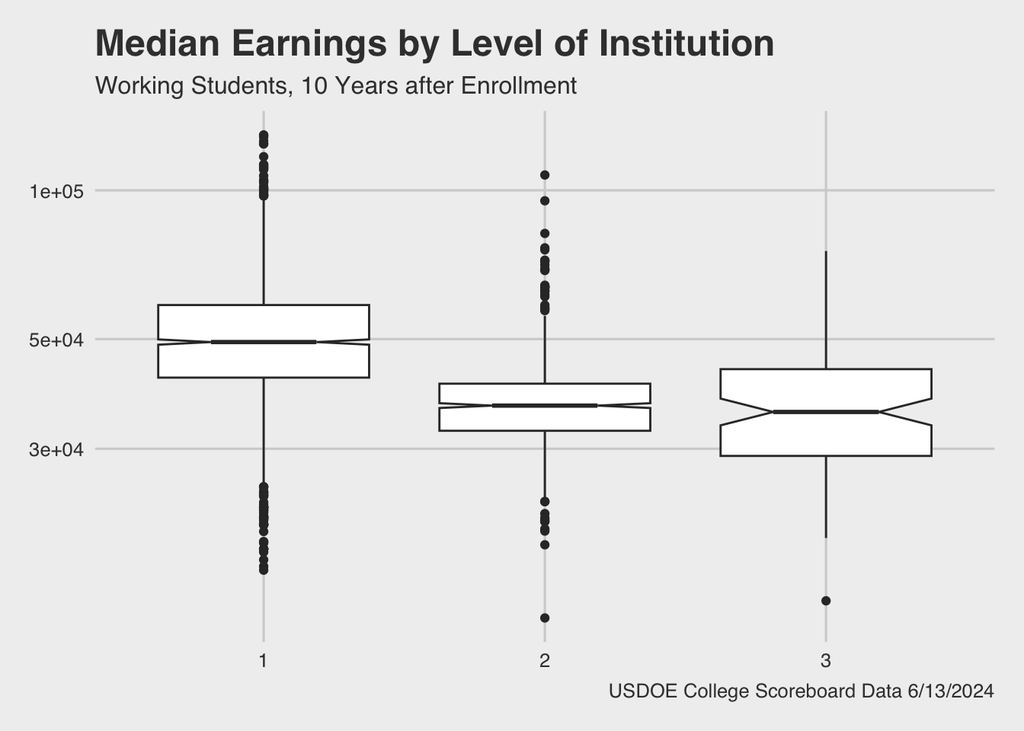

2. Interpret the plot to answer the question.
3. Use `aov()` to test if all of the institution levels have the same true mean of logged median earnings of working students ten years after enrollment.
4. Use `broom::tidy()` to show the results. Interpret the results
5. Why would we look at the log of mean earnings instead of the un-logged values?
6. Median Earnings and Percentage of Women Undergraduates
1. Create the following plot as close as you can.

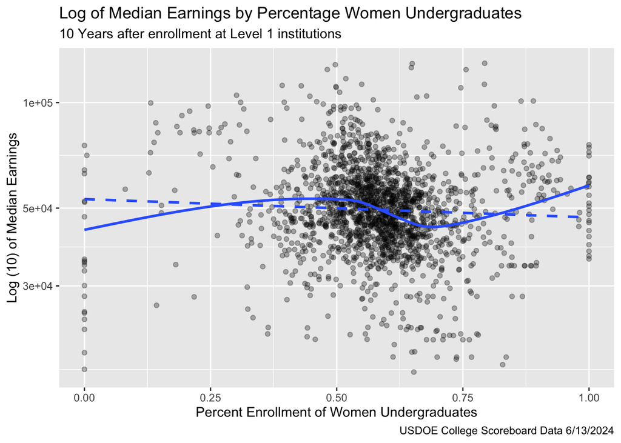

2. Pose the question you think the plot might answer and interpret the plot to answer the question. What are the implications for school administrators or for applicants?
3. Filter to only ICLEVEL 1 schools with non `NA` values for `MD_EARN_WNE_P10` and `UGDS_WOMEN`. Show the `INSTNM`, `INSTURL`, `RELAFFIL`, and `UGDS_WOMEN` with either 0% or 100% for `UGDS_WOMEN` sorted by ascending `UGDS_WOMEN` then `INSTNM`. There should be 39 schools. What do you notice?
   - Note: `RELAFFIL` of 30 is Roman Catholic, 66 is Presbyterian Church (USA), 71 is United Methodist, and 80 is Jewish.
4. To minimize extreme value effects, filter to choose ICLEVEL 1 schools where `UGDS_WOMEN` is greater than 10% and less than 90% and reproduce the plot.
   - Extra Credit: Add points and labels for American University (colored red) and the Massachusetts Institute of Technology (colored green) such that the points will automatically adjust with new data.

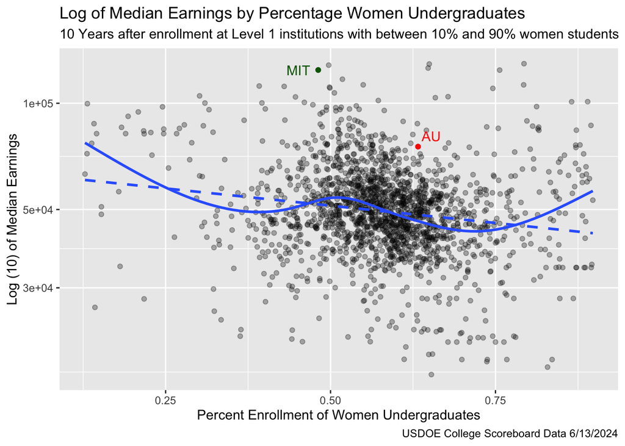

5. What do you notice? What questions does this plot raise for you?
6. Filter out the schools with `UGDS_WOMEN` less than 10% or greater than 90% and use `lm()` to run a linear model and use `summary()` on the results
7. Interpret the results compared to the plot using the sign of the coefficient for `UGDS_WOMEN`, and the model $p$-value and adjusted R-squared.
7. Median Earnings and Race/Ethnicity
1. Create the following plot as close as you can.
   - Hint: consider what shape the data should be in to generate the plot.
   - Use `geom_vline(xintercept = .36, color = "red", lty = 3)` to add the vertical line representing the maximum 90<sup>th</sup> percentile across all categories but White.

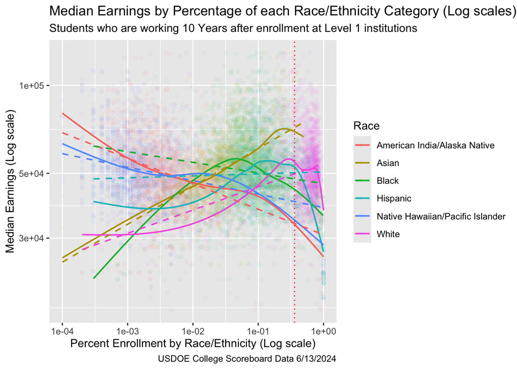

2. Pose the question you think the plot might answer and interpret the plot to answer the question.
3. What are the ethical implications of using either the linear smoother or the non-linear smoother in these plots to “prove a point”? Which would you recommend and why?
7. Rankings Based on Student Debt and Annual Cost to Attend (Debt/Cost Ratio (DCR))
1. Filter the data to only `ICLEVEL` 1 with no `NA`s for `COSTT4_A` or `GRAD_DEBT_MDN`. Also remove any satellite campuses using `filter(str_detect(OPEID, "......00"))`. That should leave 1,701 rows.
2. Add a variable called `DCR` based on the ratio of median graduation debt at graduation to the Average cost of attendance (academic year institutions).
3. Use a {dplyr} integer ranking function to compute a ranking using `DCR`. Break any ties using the smallest value and leaving a gap to the next untied DCR such that if two schools are tied for 4th, they are each ranked 4 and the next school is 6. This is similar to many sports rankings.
4. Identify the top 5 best (lowest DCR should be rank value 1) and the bottom 5 worst (largest DCR should have largest rank number). Show only the rank, name, DCR, cost to attend, median debt at graduation, and median earnings 10 years after enrollment.
5. What is American University’s rank and DCR? Show only the rank, name, DCR, cost to attend, median debt at graduation, and median earnings 10 years after enrollment.
6. Extra Credit: Reproduce the following plot so the *AU line and number of institutions automatically adjust as new data is entered*. Use `ggthemes::clean()`.

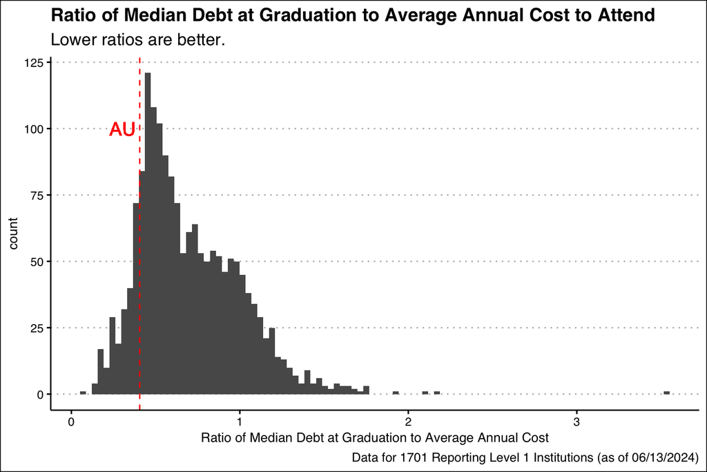

# 2 World Bank Data

The World Bank provides loans to countries with the goal of reducing poverty. The data frames in the data folder were taken from the public data repositories of the [World Bank Group DataBank](https://databank.worldbank.org/home). The fertility, life expectancy, and population data are from its [World Development Indicators (WDI)](https://databank.worldbank.org/source/world-development-indicators) as of 1 August 2024.

- `wb_country_income_classification_2023.csv`: Contains information on the countries in the data set. Also includes totals for the regions (sets of countries) and the world. Source is [World Bank Country and Lending Groups](https://datahelpdesk.worldbank.org/knowledgebase/articles/906519-world-bank-country-and-lending-groups). The variables are:
  - `Economy`: The full name of the country or region.
  - `Code`: A three-letter code for the country. Note not all rows are countries; There are rows for the regions and for the world.
  - `Region`: The region of the country. Note: The `Economy` variable includes observations for defined groups of countries, such as regions, and for the world. These have the value `NA` for `Region`.
  - `Income Group`: Either `"High income"`, `"Upper middle income"`, `"Lower middle income"`, or `"Low income"`.
  - `Lending Category`: IDA (International Development Association): Low-income countries eligible for concessional financing. Blend: Countries eligible for both IDA and International Bank for Reconstruction and Development (IBRD) assistance. IBRD (International Bank for Reconstruction and Development): Middle-income and creditworthy low-income countries.
- `wb_fertility_2022.csv`: WDI data contains the fertility rate information for each country, each region, and the world for each year.
  - For the years `1960` to `2022`, the values in the cells represent the fertility rate in total births per woman for that year.
  - Total fertility rate represents the number of children that would be born to a woman if she were to live to the end of her childbearing years and bear children in accordance with age-specific fertility rates of the specified year.
- `wb_life_exp_2022.csv`: WDI data contains the life expectancy information for each country, each region, and the world for each year.
  - For the years `1960` to `2022`, the values in the cells represent life expectancy at birth in years for the given year.
  - Life expectancy at birth indicates the number of years a newborn infant would live if prevailing patterns of mortality at the time of its birth were to stay the same throughout its life.
- `wb_pop_2023.csv`: WDI data contains the population information for each country, each region, and the world for the year.
  - For the years`1960` to `2023`, the values in the cells represent the total population in number of people for the given year.
  - Total population is based on the *de facto* definition of population, which counts all residents regardless of legal status or citizenship. The values shown are mid-year estimates.
1. Use a relative path and a {readr} function to load each of these four files into its own tibble. *Be sure to look at the data after loading to ensure it loaded as expected, without problems, and fix any problems using {readr} function arguments.* Consider using the `problems()` function to identify the locations of any problems.
   - Note: `wb_country_income_classification_2023` has a row of all `NA`s between the countries and the collective economies such as regions. The argument `skip_empty_rows` defaults to `TRUE` but, since there are commas in the file, the row is not counted as “empty.”
   - Note: Some countries have `NA` for missing data for the early years but have values in the later years which is not a problem.
   - There should be a maximum of 267 rows for the country data and 266 rows for each of the WDI data files.
2. Use `anti_join()` to show which codes are in the country data but not in the population data and which country codes are in population data but not in the country data. What do you notice?
3. These data are messy. The observational units in `fert`, `life`, and `pop` are locations in space-time (e.g., Aruba in 2020). Recall that “tidy” data should have one observational unit per row.
- Using only two function calls for each data frame, tidy each data frame to have only four variables by:
  1. Removing the `Indicator Name` and `Indicator Code` columns.
  2. Using a {tidyr} function to tidy the tibble, and, by using an argument of the function and a {readr} function ensure the variable for `year` is a numeric. Recall, {readr} parsing functions can “fix” many parsing errors automatically. There should be no need to use a `mutate()` function.
  3. Given the many `NA`s, remove them using an argument of the {tidyr} function.
  4. Save each tidy tibble to a new name.
  5. You should have four columns in each with 16,124, 16,137, and 16,930 rows based on the different numbers of `NA`s in the original tibbles. The `INX` country code had all `NA`s for each year so it should be gone as well.
- Show the first 6 rows for each tibble.
4. Combine tibbles.
1. Using a {dplyr} join function, *join* the three WDI tidy tibbles you just created into a single tibble. Start with the population data and then join fertility data and then join the life_expectancy data.
   - It should have six columns and 16,930 rows.
2. Then use a {dplyr} join function to add the data from the country tibble in a way that does not add any countries from the country data that have no data in the joined tibble. Save the resulting tibble to a new name and show the structure of the saved tibble.
   - The new tibble should now have 10 columns and 16,930 rows.
   - It should include the fertility rate, population, and life expectancy for each year as well as the `Economy`,`Region`, `IncomeGroup`, and `LendingGroup`.
5. Show just `Country Name` and `Economy` for the countries (rows with a non-`NA` value for `Region`) where the values in `Country Name` and `Economy` do not match each other. There should be five. What do you notice about they do not match?
6. Fertility vs Life Expectancy over Time by Country and Region
1. Make a single scatterplot with the following attributes:
   1. Use `drop_na()` to remove all `NA`s for the variables of interest and show fertility rate (Y) vs life expectancy (X) for Countries (i.e., rows where `Region` is not ``NA`).
   2. Color-code by `Region` and indicate the country population by size.
   3. Include only the years 1960, 1980, 2000, and 2020.
   4. Facet by these years.
   5. Use with `scale_color_viridis_d()`.
   6. Your final plot should look like the below (Each element of the plot is graded).

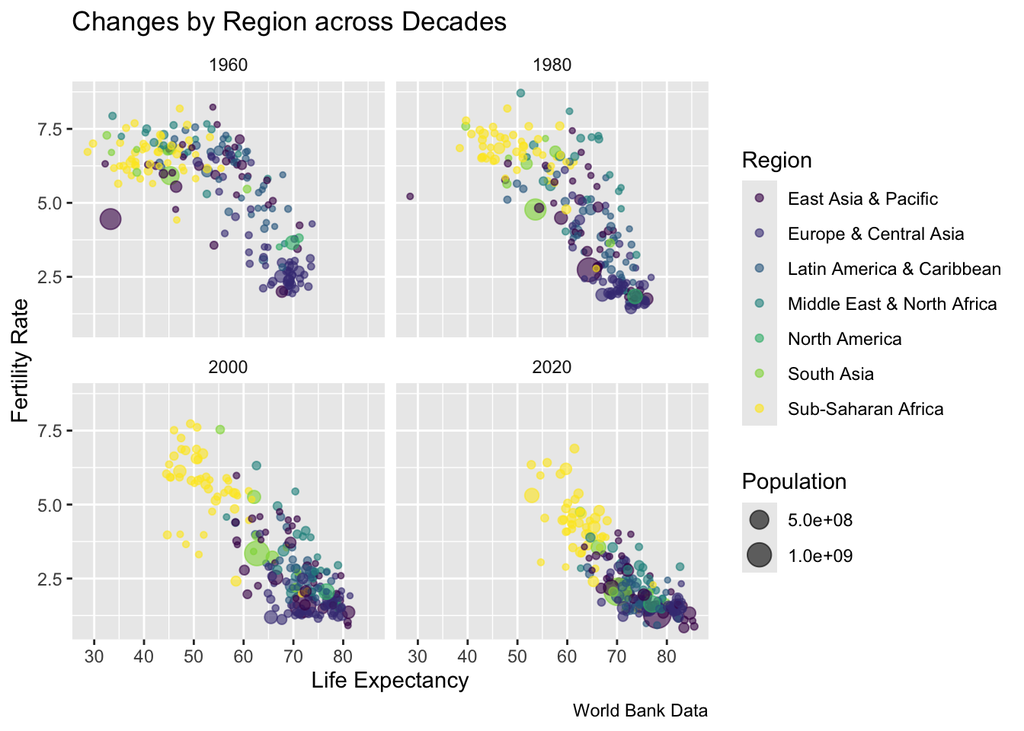

2. Interpret the plot in one sentence that address each variable.
7. Regional Population
1. Use only Countries (`Region` is not `NA`) to calculate the total population for each region for each year.
2. Make a line plot of calculated total population (Y) versus year (X), color-coding by region and using a *log scale* for Y. Use (`ggthemes::scale_color_colorblind`).
   - Your final plot should look like the below

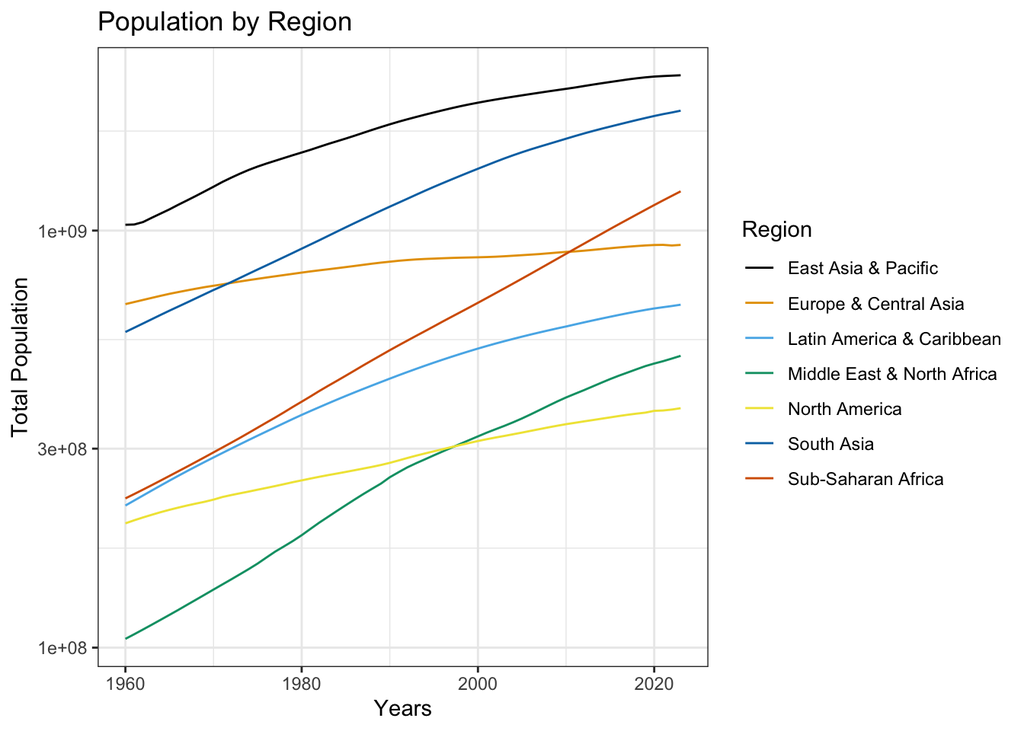

3. Interpret the plot in one sentence to identify the two fastest growing regions.
8. Percentage population growth for the countries from 1960 to 2020 (Extra Credit)
1. Make a box plot of the percentage population growth for the countries from 1960 to 2020 (the population in 2020 compared to 1960) with the following attributes.
   1. Use code to automatically order the Regions on the $y$-axis in **increasing** order of Region’s total 1960 population.
   2. For any countries with negative growth, set it to .001.
   3. Add a red line at 100%.

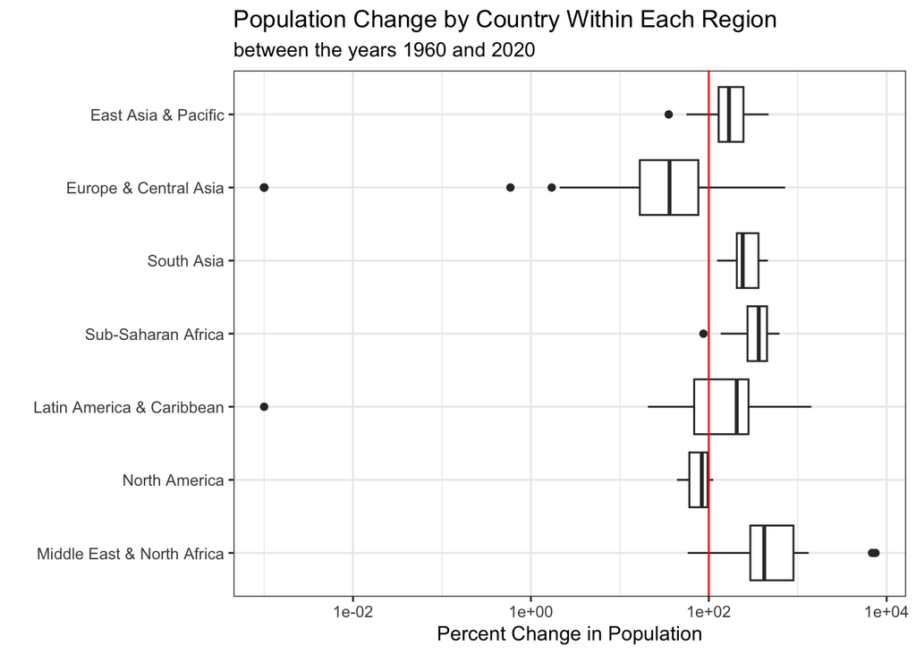

2. Interpret the plot in one sentence to compare the percentage growth with the previous plot.